# Machine Learning Workflow: Adding Nonlinearities to Predictive Modeling

Biostat 212A

Author

Dr. Jin Zhou @ UCLA

Published

May 26, 2026

Display system information for reproducibility.

**Python**

```python
import IPython
print(IPython.sys_info())
```

```
{'commit_hash': '5ed988a91',
 'commit_source': 'installation',
 'default_encoding': 'utf-8',
 'ipython_path': '/Users/jinjinzhou/.virtualenvs/r-tensorflow/lib/python3.10/site-packages/IPython',
 'ipython_version': '8.33.0',
 'os_name': 'posix',
 'platform': 'macOS-26.5-arm64-arm-64bit',
 'sys_executable': '/Users/jinjinzhou/.virtualenvs/r-tensorflow/bin/python',
 'sys_platform': 'darwin',
 'sys_version': '3.10.16 (main, Mar  3 2025, 20:01:33) [Clang 16.0.0 '
                '(clang-1600.0.26.6)]'}
```

**R**

## 1 Overview

[figure not shown]

We illustrate the typical machine learning workflow for regression problems using the `Wage` data set from R `ISLR2` package. The steps are

1. Initial splitting to test and non-test sets.
2. Pre-processing of data: one-hot-encoder for categorical variables, add nonlinear features for some continuous predictors.
3. Choose a learner/method. Elastic net in this example.
4. Tune the hyper-parameter(s) (`alpha` and `l1_ratio` in elastic net) using $K$-fold cross-validation (CV) on the non-test data.
5. Choose the best model by CV and refit it on the whole non-test data.
6. Final prediction on the test data.

These steps completes the process of training and evaluating **one** machine learning method. We repeat the same process for other learners, e.g., random forest or neural network, using the same test/non-test and CV split. The final report compares the learners based on CV and test errors.

## 2 Wage data

A documentation of the `Wage` data is [here](https://www.rdocumentation.org/packages/ISLR2/versions/1.3-2/topics/Wage). The goal is to predict the `wage`.

**R**

```r
library(GGally)
library(ISLR2)
library(tidymodels)
library(tidyverse)

Wage <- as_tibble(Wage) %>%
  select(-region) %>%
  print(width = Inf)
```

```
# A tibble: 3,000 × 10
    year   age maritl           race     education       jobclass
   <int> <int> <fct>            <fct>    <fct>           <fct>
 1  2006    18 1. Never Married 1. White 1. < HS Grad    1. Industrial
 2  2004    24 1. Never Married 1. White 4. College Grad 2. Information
 3  2003    45 2. Married       1. White 3. Some College 1. Industrial
 4  2003    43 2. Married       3. Asian 4. College Grad 2. Information
 5  2005    50 4. Divorced      1. White 2. HS Grad      2. Information
 6  2008    54 2. Married       1. White 4. College Grad 2. Information
 7  2009    44 2. Married       4. Other 3. Some College 1. Industrial
 8  2008    30 1. Never Married 3. Asian 3. Some College 2. Information
 9  2006    41 1. Never Married 2. Black 3. Some College 2. Information
10  2004    52 2. Married       1. White 2. HS Grad      2. Information
   health         health_ins logwage  wage
   <fct>          <fct>        <dbl> <dbl>
 1 1. <=Good      2. No         4.32  75.0
 2 2. >=Very Good 2. No         4.26  70.5
 3 1. <=Good      1. Yes        4.88 131.
 4 2. >=Very Good 1. Yes        5.04 155.
 5 1. <=Good      1. Yes        4.32  75.0
 6 2. >=Very Good 1. Yes        4.85 127.
 7 2. >=Very Good 1. Yes        5.13 170.
 8 1. <=Good      1. Yes        4.72 112.
 9 2. >=Very Good 1. Yes        4.78 119.
10 2. >=Very Good 1. Yes        4.86 129.
# ℹ 2,990 more rows
```

```r
# Numerical summaries
summary(Wage)
```

```
      year           age                     maritl           race
 Min.   :2003   Min.   :18.00   1. Never Married: 648   1. White:2480
 1st Qu.:2004   1st Qu.:33.75   2. Married      :2074   2. Black: 293
 Median :2006   Median :42.00   3. Widowed      :  19   3. Asian: 190
 Mean   :2006   Mean   :42.41   4. Divorced     : 204   4. Other:  37
 3rd Qu.:2008   3rd Qu.:51.00   5. Separated    :  55
 Max.   :2009   Max.   :80.00
              education             jobclass               health
 1. < HS Grad      :268   1. Industrial :1544   1. <=Good     : 858
 2. HS Grad        :971   2. Information:1456   2. >=Very Good:2142
 3. Some College   :650
 4. College Grad   :685
 5. Advanced Degree:426

  health_ins      logwage           wage
 1. Yes:2083   Min.   :3.000   Min.   : 20.09
 2. No : 917   1st Qu.:4.447   1st Qu.: 85.38
               Median :4.653   Median :104.92
               Mean   :4.654   Mean   :111.70
               3rd Qu.:4.857   3rd Qu.:128.68
               Max.   :5.763   Max.   :318.34
```

Graphical summary takes longer to run so suppressed here.

```r
# Graphical summaries
ggpairs(
  data = Wage,
  mapping = aes(alpha = 0.25),
  lower = list(continuous = "smooth")
  ) +
  labs(title = "Wage Data")
```

**Python**

```python
# Load the pandas library
import pandas as pd
# Load numpy for array manipulation
import numpy as np
# Load seaborn plotting library
import seaborn as sns
import matplotlib.pyplot as plt

# Set font sizes in plots
sns.set(font_scale = 1.2)
# Display all columns
pd.set_option('display.max_columns', None)

Wage = pd.read_csv("Wage.csv").drop(['logwage', 'region'], axis = 1)
Wage
```

```
      year  age            maritl      race        education        jobclass  \
0     2006   18  1. Never Married  1. White     1. < HS Grad   1. Industrial
1     2004   24  1. Never Married  1. White  4. College Grad  2. Information
2     2003   45        2. Married  1. White  3. Some College   1. Industrial
3     2003   43        2. Married  3. Asian  4. College Grad  2. Information
4     2005   50       4. Divorced  1. White       2. HS Grad  2. Information
...    ...  ...               ...       ...              ...             ...
2995  2008   44        2. Married  1. White  3. Some College   1. Industrial
2996  2007   30        2. Married  1. White       2. HS Grad   1. Industrial
2997  2005   27        2. Married  2. Black     1. < HS Grad   1. Industrial
2998  2005   27  1. Never Married  1. White  3. Some College   1. Industrial
2999  2009   55      5. Separated  1. White       2. HS Grad   1. Industrial

              health health_ins        wage
0          1. <=Good      2. No   75.043154
1     2. >=Very Good      2. No   70.476020
2          1. <=Good     1. Yes  130.982177
3     2. >=Very Good     1. Yes  154.685293
4          1. <=Good     1. Yes   75.043154
...              ...        ...         ...
2995  2. >=Very Good     1. Yes  154.685293
2996  2. >=Very Good      2. No   99.689464
2997       1. <=Good      2. No   66.229408
2998  2. >=Very Good     1. Yes   87.981033
2999       1. <=Good     1. Yes   90.481913

[3000 rows x 9 columns]
```

```python
# Numerical summaries
Wage.describe()
```

```
              year          age         wage
count  3000.000000  3000.000000  3000.000000
mean   2005.791000    42.414667   111.703608
std       2.026167    11.542406    41.728595
min    2003.000000    18.000000    20.085537
25%    2004.000000    33.750000    85.383940
50%    2006.000000    42.000000   104.921507
75%    2008.000000    51.000000   128.680488
max    2009.000000    80.000000   318.342430
```

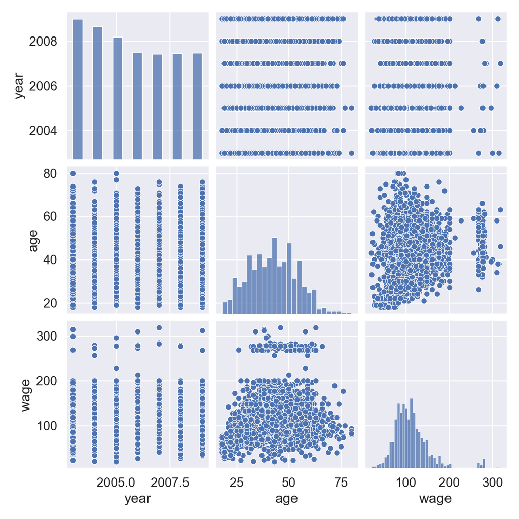

```python
# Graphical summaries
plt.figure()
sns.pairplot(data = Wage);
plt.show()
```

## 3 Initial split into test and non-test sets

**R**

```r
# For reproducibility
set.seed(425)
data_split <- initial_split(
  Wage,
  # # stratify by percentiles
  # strata = "Salary",
  prop = 0.75
  )

Wage_other <- training(data_split)
dim(Wage_other)
```

```
[1] 2250   10
```

```r
Wage_test <- testing(data_split)
dim(Wage_test)
```

```
[1] 750  10
```

**Python**

```python
from sklearn.model_selection import train_test_split

Wage_other, Wage_test = train_test_split(
  Wage,
  train_size = 0.75,
  random_state = 425, # seed
  )
Wage_test.shape
```

```
(750, 9)
```

```python
Wage_other.shape
```

```
(2250, 9)
```

Separate $X$ and $y$.

```python
# Non-test X and y
X_other = Wage_other.drop(['wage'], axis = 1)
y_other = Wage_other.wage
# Test X and y
X_test = Wage_test.drop(['wage'], axis = 1)
y_test = Wage_test.wage
```

## 4 Preprocessing (Python) or recipe (R)

For regularization methods such as ridge and lasso, it is essential to center and scale predictors.

**R**

```r
norm_recipe <-
  recipe(
    wage ~ .,
    data = Wage_other
  ) %>%
  # create traditional dummy variables
  step_dummy(all_nominal()) %>%
  # zero-variance filter
  step_zv(all_predictors()) %>%
  # B-splines of age
  step_bs(age, deg_free = 5) %>%
  # B-splines of year
  step_bs(year, deg_free = 4) %>%
  # center and scale numeric data
  step_normalize(all_predictors()) # %>%
  # estimate the means and standard deviations
  #prep(training = Wage_other, retain = TRUE)
norm_recipe
```

[output not shown]

**Python**

Pre-processor for one-hot coding of categorical variables and then standardizing all numeric predictors.

```python
from sklearn.preprocessing import OneHotEncoder, StandardScaler, SplineTransformer
from sklearn.compose import make_column_transformer
from sklearn.pipeline import Pipeline


col_tf = make_column_transformer(
  # OHE transformer for categorical variables
  (OneHotEncoder(drop = 'first'), ['maritl', 'race', 'education', 'jobclass', 'health', 'health_ins']),
  # Nonlinear features by splines of age and year
  (SplineTransformer(
    degree = 3,
    n_knots = 5,
    extrapolation = 'linear'
    ), ['age']),
  (SplineTransformer(
    degree = 3,
    n_knots = 4,
    extrapolation = 'linear'
    ), ['year']),
  remainder = 'passthrough'
)
# Standardization transformer
std_tf = StandardScaler()
```

## 5 Model

**R**

```r
enet_mod <-
  # mixture = 0 (ridge), mixture = 1 (lasso)
  linear_reg(penalty = tune(), mixture = tune()) %>%
  set_engine("glmnet")
enet_mod
```

```
Linear Regression Model Specification (regression)

Main Arguments:
  penalty = tune()
  mixture = tune()

Computational engine: glmnet
```

**Python**

```python
from sklearn.linear_model import ElasticNet

enet_mod = ElasticNet()
enet_mod
```

```
ElasticNet()
```

## 6 Pipeline (Python) or workflow (R)

Here we bundle the preprocessing step (Python) or recipe (R) and model.

**R**

```r
lr_wf <-
  workflow() %>%
  add_model(enet_mod) %>%
  add_recipe(norm_recipe)
lr_wf
```

```
══ Workflow ════════════════════════════════════════════════════════════════════
Preprocessor: Recipe
Model: linear_reg()

── Preprocessor ────────────────────────────────────────────────────────────────
5 Recipe Steps

• step_dummy()
• step_zv()
• step_bs()
• step_bs()
• step_normalize()

── Model ───────────────────────────────────────────────────────────────────────
Linear Regression Model Specification (regression)

Main Arguments:
  penalty = tune()
  mixture = tune()

Computational engine: glmnet
```

**Python**

```python
pipe = Pipeline(steps = [
  ("col_tf", col_tf),
  ("std_tf", std_tf),
  ("model", enet_mod)
  ])
pipe
```

```
Pipeline(steps=[('col_tf',
                 ColumnTransformer(remainder='passthrough',
                                   transformers=[('onehotencoder',
                                                  OneHotEncoder(drop='first'),
                                                  ['maritl', 'race',
                                                   'education', 'jobclass',
                                                   'health', 'health_ins']),
                                                 ('splinetransformer-1',
                                                  SplineTransformer(extrapolation='linear'),
                                                  ['age']),
                                                 ('splinetransformer-2',
                                                  SplineTransformer(extrapolation='linear',
                                                                    n_knots=4),
                                                  ['year'])])),
                ('std_tf', StandardScaler()), ('model', ElasticNet())])
```

## 7 Tuning grid

Set up the 2D grid for tuning.

**R**

```r
param_grid <-grid_regular(
  penalty(range = c(-5, 0), trans = log10_trans()),
  mixture(range = c(0, 1)),
  levels = c(penalty = 50, mixture = 6)
  )
param_grid
```

```
# A tibble: 300 × 2
     penalty mixture
       <dbl>   <dbl>
 1 0.00001         0
 2 0.0000126       0
 3 0.0000160       0
 4 0.0000202       0
 5 0.0000256       0
 6 0.0000324       0
 7 0.0000409       0
 8 0.0000518       0
 9 0.0000655       0
10 0.0000829       0
# ℹ 290 more rows
```

**Python**

```python
# Tune hyper-parameter(s)
alphas = np.logspace(start = -6, stop = -1, base = 10, num = 50)
l1_ratios = np.linspace(start = 0, stop = 1, num = 6)
# n_knots = [2, 3, 4, 5]
tuned_parameters = {
  "model__alpha": alphas,
  "model__l1_ratio": l1_ratios
  # "bs_tf__n_knots": n_knots
  }
tuned_parameters
```

```
{'model__alpha': array([1.00000000e-06, 1.26485522e-06, 1.59985872e-06, 2.02358965e-06,
       2.55954792e-06, 3.23745754e-06, 4.09491506e-06, 5.17947468e-06,
       6.55128557e-06, 8.28642773e-06, 1.04811313e-05, 1.32571137e-05,
       1.67683294e-05, 2.12095089e-05, 2.68269580e-05, 3.39322177e-05,
       4.29193426e-05, 5.42867544e-05, 6.86648845e-05, 8.68511374e-05,
       1.09854114e-04, 1.38949549e-04, 1.75751062e-04, 2.22299648e-04,
       2.81176870e-04, 3.55648031e-04, 4.49843267e-04, 5.68986603e-04,
       7.19685673e-04, 9.10298178e-04, 1.15139540e-03, 1.45634848e-03,
       1.84206997e-03, 2.32995181e-03, 2.94705170e-03, 3.72759372e-03,
       4.71486636e-03, 5.96362332e-03, 7.54312006e-03, 9.54095476e-03,
       1.20679264e-02, 1.52641797e-02, 1.93069773e-02, 2.44205309e-02,
       3.08884360e-02, 3.90693994e-02, 4.94171336e-02, 6.25055193e-02,
       7.90604321e-02, 1.00000000e-01]), 'model__l1_ratio': array([0. , 0.2, 0.4, 0.6, 0.8, 1. ])}
```

## 8 Cross-validation (CV)

**R**

Set cross-validation partitions.

```r
set.seed(250)
folds <- vfold_cv(Wage_other, v = 10)
folds
```

```
#  10-fold cross-validation
# A tibble: 10 × 2
   splits             id
   <list>             <chr>
 1 <split [2025/225]> Fold01
 2 <split [2025/225]> Fold02
 3 <split [2025/225]> Fold03
 4 <split [2025/225]> Fold04
 5 <split [2025/225]> Fold05
 6 <split [2025/225]> Fold06
 7 <split [2025/225]> Fold07
 8 <split [2025/225]> Fold08
 9 <split [2025/225]> Fold09
10 <split [2025/225]> Fold10
```

Fit cross-validation.

```r
enet_fit <-
  lr_wf %>%
  tune_grid(
    resamples = folds,
    grid = param_grid,
    )
enet_fit
```

```
# Tuning results
# 10-fold cross-validation
# A tibble: 10 × 4
   splits             id     .metrics           .notes
   <list>             <chr>  <list>             <list>
 1 <split [2025/225]> Fold01 <tibble [600 × 6]> <tibble [0 × 4]>
 2 <split [2025/225]> Fold02 <tibble [600 × 6]> <tibble [0 × 4]>
 3 <split [2025/225]> Fold03 <tibble [600 × 6]> <tibble [0 × 4]>
 4 <split [2025/225]> Fold04 <tibble [600 × 6]> <tibble [0 × 4]>
 5 <split [2025/225]> Fold05 <tibble [600 × 6]> <tibble [0 × 4]>
 6 <split [2025/225]> Fold06 <tibble [600 × 6]> <tibble [0 × 4]>
 7 <split [2025/225]> Fold07 <tibble [600 × 6]> <tibble [0 × 4]>
 8 <split [2025/225]> Fold08 <tibble [600 × 6]> <tibble [0 × 4]>
 9 <split [2025/225]> Fold09 <tibble [600 × 6]> <tibble [0 × 4]>
10 <split [2025/225]> Fold10 <tibble [600 × 6]> <tibble [0 × 4]>
```

Visualize CV criterion.

```
# A tibble: 600 × 8
   penalty mixture .metric .estimator   mean     n std_err .config
     <dbl>   <dbl> <chr>   <chr>       <dbl> <int>   <dbl> <chr>
 1 0.00001     0   rmse    standard   13.4      10 0.362   pre0_mod001_post0
 2 0.00001     0   rsq     standard    0.905    10 0.00427 pre0_mod001_post0
 3 0.00001     0.2 rmse    standard   12.7      10 0.411   pre0_mod002_post0
 4 0.00001     0.2 rsq     standard    0.910    10 0.00501 pre0_mod002_post0
 5 0.00001     0.4 rmse    standard   12.7      10 0.413   pre0_mod003_post0
 6 0.00001     0.4 rsq     standard    0.910    10 0.00502 pre0_mod003_post0
 7 0.00001     0.6 rmse    standard   12.7      10 0.413   pre0_mod004_post0
 8 0.00001     0.6 rsq     standard    0.910    10 0.00503 pre0_mod004_post0
 9 0.00001     0.8 rmse    standard   12.7      10 0.414   pre0_mod005_post0
10 0.00001     0.8 rsq     standard    0.910    10 0.00503 pre0_mod005_post0
# ℹ 590 more rows
```

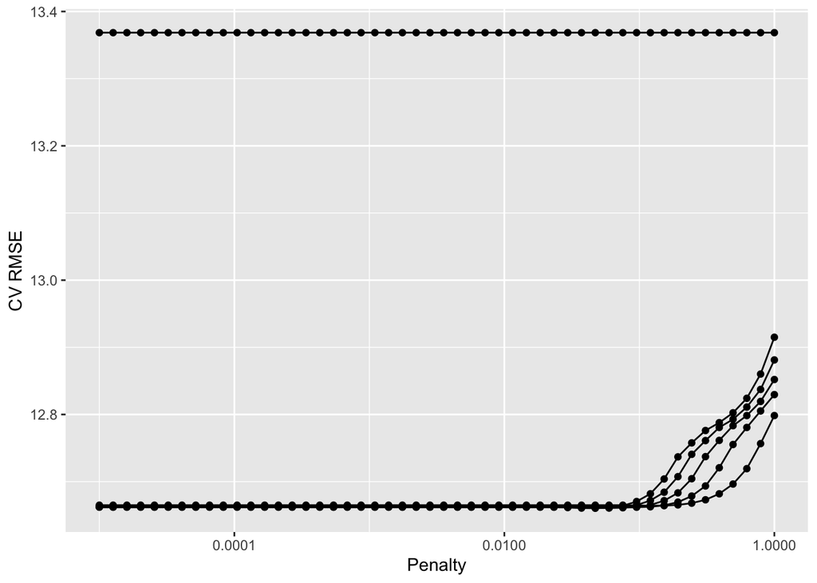

```r
enet_fit %>%
  collect_metrics() %>%
  print(width = Inf) %>%
  filter(.metric == "rmse") %>%
  ggplot(mapping = aes(x = penalty, y = mean)) +
  geom_point() +
  geom_line(aes(group = mixture)) +
  labs(x = "Penalty", y = "CV RMSE") +
  scale_x_log10(labels = scales::label_number())
```

Show the top 5 models ($\lambda$ values)

```r
enet_fit %>%
  show_best(metric = "rmse")
```

```
# A tibble: 5 × 8
  penalty mixture .metric .estimator  mean     n std_err .config
    <dbl>   <dbl> <chr>   <chr>      <dbl> <int>   <dbl> <chr>
1  0.0471     1   rmse    standard    12.7    10   0.414 pre0_mod222_post0
2  0.0373     1   rmse    standard    12.7    10   0.414 pre0_mod216_post0
3  0.0596     0.8 rmse    standard    12.7    10   0.414 pre0_mod227_post0
4  0.0471     0.8 rmse    standard    12.7    10   0.414 pre0_mod221_post0
5  0.0596     1   rmse    standard    12.7    10   0.414 pre0_mod228_post0
```

Let’s select the best model

```r
best_enet <- enet_fit %>%
  select_best(metric = "rmse")
best_enet
```

```
# A tibble: 1 × 3
  penalty mixture .config
    <dbl>   <dbl> <chr>
1  0.0471       1 pre0_mod222_post0
```

**Python**

Set up CV partitions and CV criterion.

```python
from sklearn.model_selection import GridSearchCV

# Set up CV
n_folds = 10
search = GridSearchCV(
  pipe,
  tuned_parameters,
  cv = n_folds,
  scoring = "neg_root_mean_squared_error",
  # Refit the best model on the whole data set
  refit = True
  )
```

Fit CV. This is typically the most time-consuming step.

```python
# Fit CV
search.fit(X_other, y_other)
```

```
GridSearchCV(cv=10,
             estimator=Pipeline(steps=[('col_tf',
                                        ColumnTransformer(remainder='passthrough',
                                                          transformers=[('onehotencoder',
                                                                         OneHotEncoder(drop='first'),
                                                                         ['maritl',
                                                                          'race',
                                                                          'education',
                                                                          'jobclass',
                                                                          'health',
                                                                          'health_ins']),
                                                                        ('splinetransformer-1',
                                                                         SplineTransformer(extrapolation='linear'),
                                                                         ['age']),
                                                                        ('splinetransformer-2',
                                                                         SplineTransformer(extrapolation='...
       1.84206997e-03, 2.32995181e-03, 2.94705170e-03, 3.72759372e-03,
       4.71486636e-03, 5.96362332e-03, 7.54312006e-03, 9.54095476e-03,
       1.20679264e-02, 1.52641797e-02, 1.93069773e-02, 2.44205309e-02,
       3.08884360e-02, 3.90693994e-02, 4.94171336e-02, 6.25055193e-02,
       7.90604321e-02, 1.00000000e-01]),
                         'model__l1_ratio': array([0. , 0.2, 0.4, 0.6, 0.8, 1. ])},
             scoring='neg_root_mean_squared_error')
```

Visualize CV results (TODO).

```python
cv_res = pd.DataFrame({
  "alpha": alphas,
  "rmse": -search.cv_results_["mean_test_score"]
  })

plt.figure()
sns.relplot(
  data = cv_res,
  x = "alpha",
  y = "rmse"
  ).set(
    xlabel = "alpha",
    ylabel = "CV RMSE",
    xscale = "log"
);
plt.show()
```

[output not shown]

Best CV RMSE:

```python
-search.best_score_
```

```
np.float64(33.80941591090395)
```

## 9 Finalize our model

Now we are done tuning. Finally, let’s fit this final model to the whole training data and use our test data to estimate the model performance we expect to see with new data.

**R**

```r
# Final workflow
final_wf <- lr_wf %>%
  finalize_workflow(best_enet)
final_wf
```

```
══ Workflow ════════════════════════════════════════════════════════════════════
Preprocessor: Recipe
Model: linear_reg()

── Preprocessor ────────────────────────────────────────────────────────────────
5 Recipe Steps

• step_dummy()
• step_zv()
• step_bs()
• step_bs()
• step_normalize()

── Model ───────────────────────────────────────────────────────────────────────
Linear Regression Model Specification (regression)

Main Arguments:
  penalty = 0.0471486636345739
  mixture = 1

Computational engine: glmnet
```

```r
# Fit the whole training set, then predict the test cases
final_fit <-
  final_wf %>%
  last_fit(data_split)
final_fit
```

```
# Resampling results
# Manual resampling
# A tibble: 1 × 6
  splits             id               .metrics .notes   .predictions .workflow
  <list>             <chr>            <list>   <list>   <list>       <list>
1 <split [2250/750]> train/test split <tibble> <tibble> <tibble>     <workflow>
```

```r
# Test metrics
final_fit %>% collect_metrics()
```

```
# A tibble: 2 × 4
  .metric .estimator .estimate .config
  <chr>   <chr>          <dbl> <chr>
1 rmse    standard      12.0   pre0_mod0_post0
2 rsq     standard       0.915 pre0_mod0_post0
```

**Python**

Since we called `GridSearchCV` with `refit = True`, the best model fit on the whole non-test data is readily available.

```python
search.best_estimator_
```

```
Pipeline(steps=[('col_tf',
                 ColumnTransformer(remainder='passthrough',
                                   transformers=[('onehotencoder',
                                                  OneHotEncoder(drop='first'),
                                                  ['maritl', 'race',
                                                   'education', 'jobclass',
                                                   'health', 'health_ins']),
                                                 ('splinetransformer-1',
                                                  SplineTransformer(extrapolation='linear'),
                                                  ['age']),
                                                 ('splinetransformer-2',
                                                  SplineTransformer(extrapolation='linear',
                                                                    n_knots=4),
                                                  ['year'])])),
                ('std_tf', StandardScaler()),
                ('model',
                 ElasticNet(alpha=np.float64(0.1), l1_ratio=np.float64(1.0)))])
```

The final prediction RMSE on the test set is

```python
from sklearn.metrics import root_mean_squared_error

root_mean_squared_error(
    y_test,
    search.best_estimator_.predict(X_test)
)
```

```
33.77484584348061
```